# Prostate Cancer DREAM Challenge

Niels Richard Hansen, Ann-Sophie Buchardt, Maria Bekker-Nielsen Dunbar, Anne Helby Petersen, Lisbeth Tomaziu

University of Copenhagen

July 27, 2015

# Introduction

For the prediction of risk scores for the Prostate Cancer DREAM Challenge we used Cox’s proportional hazards model in combination with variable selection and/or penalization. The data analysis and model building was carried out in R. This document includes a brief description of our work, and the computations required for fitting the final model are embedded as R code in the Results section.

It quickly became clear from the initial data analysis that two of the main challenges were how to deal with the variable selection and how to handle missing values. The logitudinal data provided in addition to the core table was also explored, but it was not obvious how to use the information in these tables besides some investigations of data quality and consistency.

The model we ended up with was a fairly standard model that did not differ much from the model presented by Halabi et al. except that it was a generalized additive model (a gam) that allows for nonlinear relations between continuous predictors and the log-hazard. This model used only nine predictor variables.

We experimented with one way of extracting additional predictive information from the many variables not included in the gam. This is described further in the two sections Methods and Results below, but whether it produced any actual increase of performance in terms of iAUC was uncertain.

# Methods

The following presentation of the methods refers only to the use of the core table. We did not use the longitudinal data tables for the actual modeling. Moreover, this section does not describe any of the training-test data splits we did on the training data to test out how well our methods could be expected to work. The section only documents how the final models were fitted to the full data set and how the predictions were computed on the validation data.

## Initial data cleaning

The variables HGTBLCAT, WGTBLCAT, HEAD_AND_NECK, PANCREAS, THYROID, CREACLCA, CREACL, GLEAS_DX and STOMACH were removed from the core table as these variables have no or limited variation in the training data.

For the training data a single PSA value (Patient ID VEN-756003601) was changed from 0 to 0.01, and a single ECOG value (Patient ID CELG-00121) was changed from 3 to 2.

For both the training and the validation data sets the ECOG variable was converted to a factor.

## Missing values and imputation

Some of the variables, lab values in particular, have many missing values. We investigated several imputation methods, but our conclusion was that the more complicated imputation methods resulted in worse predictive performance. Thus we ended up with a very simple imputation method, which in principle relies on a missing completely at random assumption.

For each variable we imputed missing values by sampling with replacement from the observed values of that variable in the training data.

## Variable selection

We used lasso penalization with Cox’s partial log-likelihood as implemented in the R package *glmnet* in combination with a form of stability selection for the variable selection.

This was carried out by fitting the lasso path to 100 subsamples of the training data of half the size of the initial data set. For each subsample the optimal choice of penalty parameter was selected by cross-validation (as implemented in the `cv.glmnet` function in the *glmnet* package), and the variables corresponding to the non-zero parameters were selected. The proportion of times each variable was selected was then computed across the 100 subsamples. The variables most frequently selected by the lasso procedure were then selected for further modeling.

## Generalized additive model

Based on the selected variables by the lasso procedure and some additional considerations about the final model, a generalized additive proportional hazards model was fitted using the `gam` function in the *mgcv* package with the `cox.ph` family.

The fitting of a gam uses a basis expansion of all continuous predictors in combination with penalized likelihood estimation. The *mgcv* package supports an automatic selection of penalty parameters, which was used.

## Improvements based on ridge regression

To include potential predictive information in the variables not selected we fitted a model using a ridge regression penalty as implemented in the R package *glmnet* including all predictors considered for the variable selection step. The final risk prediction was obtained as a weighted linear combination of the risk prediction from the gam and the ridge model.

## Prediction of time-to-event

# Results

The predictions were obtained by running the code below. The raw code is found in the file *Write-up.R*.

```r
library(ggplot2)
library(survival)
library(glmnet)
library(mgcv)
```

## Data cleaning

In one of the data cleaning stesp below, all values that were equal to the empty string were converted to `"No"`.

```r
load("../Data/Prostate_all.RData")
training <- CoreTable_training
validation <- CoreTable_validation

discard <-  c("HGTBLCAT", "WGTBLCAT", "HEAD_AND_NECK",
              "PANCREAS", "THYROID", "CREACLCA", "CREACL",
              "GLEAS_DX", "STOMACH")
training <- subset(training, select = -which(colnames(training) %in% discard))
validation <- subset(validation, select = -which(colnames(validation) %in% discard))

training <- transform(training,
                      PSA = ifelse(PSA == 0, 0.01, PSA),
                      ECOG_C = factor((ECOG_C >= 1) + (ECOG_C >= 2)))
validation <- transform(validation,
                        ECOG_C = factor((ECOG_C >= 1) + (ECOG_C >= 2)))

for (i in seq_len(ncol(training))) {
  if (is.factor(training[, i])) {
    tmp <- as.character(training[, i])
    tmp[tmp == ""] <- "No"
    training[, i] <- factor(tmp)
  }
}

for (i in seq_len(ncol(validation))) {
  if (is.factor(validation[, i])) {
    tmp <- as.character(validation[, i])
    tmp[tmp == ""] <- "No"
    validation[, i] <- factor(tmp)
    name <- colnames(validation)[i]
    if (name %in% colnames(training) &&
          !identical(levels(validation[, i]), levels(training[, name])))
      validation[, i] <- factor(tmp, levels(training[, name]))
  }
}
```

## Imputation

The implemented imputation scheme consisted of sampling from the marginal empirical distributions from the training data for each variable.

```r
set.seed(1234)
for (i in seq(1, ncol(training))) {
  x0 <- training[, i]
  nas <- is.na(x0)
  if (!all(nas)) {
    if (any(nas))
      training[nas, i] <- sample(x0[!nas], sum(nas), replace = TRUE)
    name <- names(training)[i]
    if(name %in% names(validation)) {
      nasLeader <- is.na(validation[, name])
      if (any(nasLeader))
        validation[nasLeader, name] <- sample(x0[!nas], sum(nasLeader), replace = TRUE)
    }
  }
}
```

## Variable selection

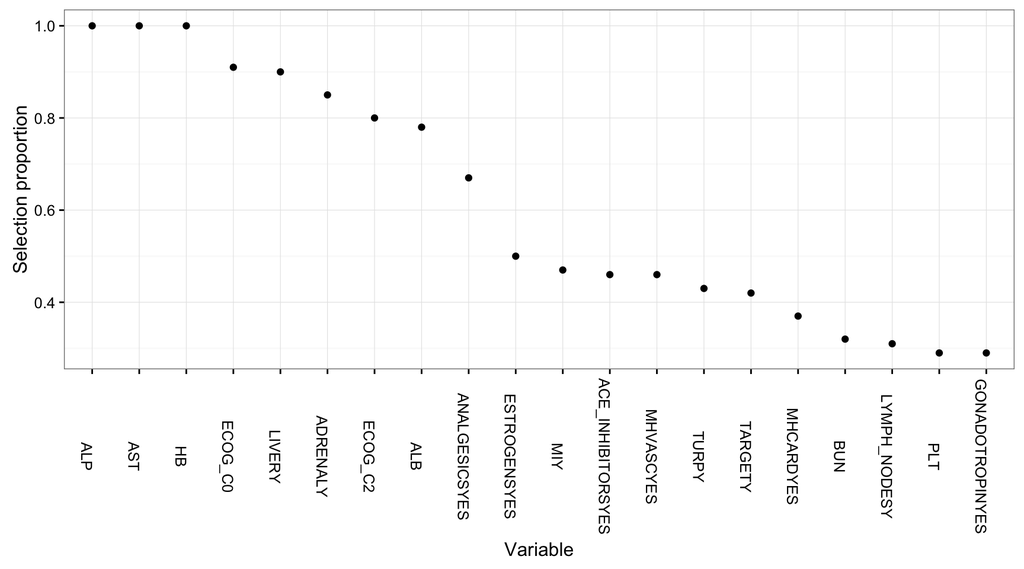

```r
variables <-  c(23, 27:ncol(training))
train <- training[, c(4, 5, variables)]
XX0 <- XX <- model.matrix(~ . - 1, train[, -c(1, 2)])
YY <- Surv(train$LKADT_P, train$DEATH == "YES")

n <- nrow(XX)
p <- ncol(XX)
B <- 100
select <- matrix(0, p, B)
rownames(select) <- colnames(XX)

for (b in seq_len(B)) {
  ii <- sample(n, n / 2 )
  survNet <- cv.glmnet(XX[ii, ], YY[ii, ], family = "cox")
  betahat <- coef(survNet, s = "lambda.min")
  select[, b] <- as.numeric(betahat != 0)
}

selectFreq <- rowSums(select) / B
selectFreq <- sort(selectFreq, decreasing = TRUE)
varSort <- factor(names(selectFreq), levels = names(selectFreq))
qplot(varSort[1:20], selectFreq[1:20]) +
  theme(axis.text.x = element_text(angle = -90)) +
  scale_y_continuous("Selection proportion") +
  scale_x_discrete("Variable")
```

The variable selection procedure shows that the eight variables ALP, AST, HB, ECOG, LIVER, ADRENAL, ALB and ANALGESICS are the most stably selected variables, all selected in more than 60% of the models.

In addition to these eight variables we included PSA and LYMPH_NODES, which were suspected to be predictive based on the study by Halabi et al., and found to be so in our studies as well.

## Gam

```r
form <- LKADT_P ~ s(log(ALP)) + s(HB) + s(log(AST)) + s(log(PSA)) + s(ALB) +
  ECOG_C + LIVER + ADRENAL + LYMPH_NODES + ANALGESICS
survGam <- gam(form, data = training, family = cox.ph(), weight = DEATH == "YES")
summary(survGam)
```

```
##
## Family: Cox PH
## Link function: identity
##
## Formula:
## LKADT_P ~ s(log(ALP)) + s(HB) + s(log(AST)) + s(log(PSA)) + s(ALB) +
##     ECOG_C + LIVER + ADRENAL + LYMPH_NODES + ANALGESICS
##
## Parametric coefficients:
##               Estimate Std. Error z value Pr(>|z|)
## ECOG_C1        0.19669    0.08475   2.321  0.02030 *
## ECOG_C2        0.55074    0.17385   3.168  0.00154 **
## LIVERY         0.39505    0.12764   3.095  0.00197 **
## ADRENALY       0.73817    0.22477   3.284  0.00102 **
## LYMPH_NODESY   0.21123    0.07937   2.661  0.00778 **
## ANALGESICSYES  0.07936    0.08694   0.913  0.36131
## ---
## Signif. codes:  0 '***' 0.001 '**' 0.01 '*' 0.05 '.' 0.1 ' ' 1
##
## Approximate significance of smooth terms:
##               edf Ref.df Chi.sq  p-value
## s(log(ALP)) 2.535  3.213  43.38 4.29e-09 ***
## s(HB)       1.002  1.004  19.05 1.30e-05 ***
## s(log(AST)) 2.005  2.605  15.83  0.00085 ***
## s(log(PSA)) 3.641  4.586  11.85  0.02986 *
## s(ALB)      1.003  1.005   5.73  0.01688 *
## ---
## Signif. codes:  0 '***' 0.001 '**' 0.01 '*' 0.05 '.' 0.1 ' ' 1
##
## Deviance explained = 10.2%
## -REML = 4144.1  Scale est. = 1         n = 1600
```

The effect of ANALGESICS was not significant in this model, and it was removed from the model.

```r
survGam <- update(survGam, . ~ . - ANALGESICS)
```

## Risk predictions

As mentioned in Methods, the final risk predictions were given as a linear combination of the risk predictions from the gam and the risk predictions from the ridge regression model. The ridge model was fitted using the `cv.glmnet` function with `alpha = 0`. The penalty parameter was selected by cross-validation choosing the model with the minimal cross-validated negative partial log-likelihood.

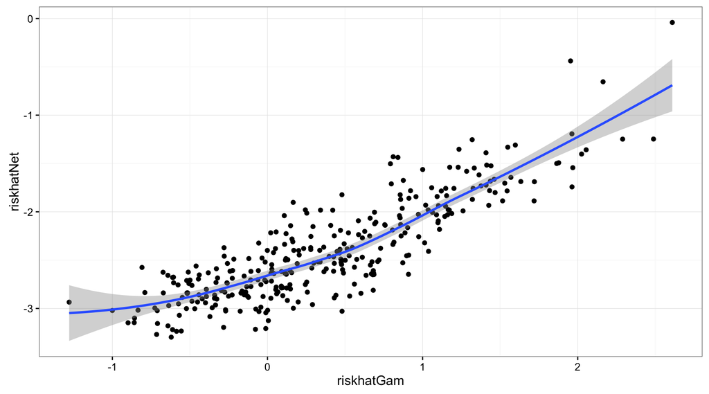

```r
survNet <- cv.glmnet(XX, YY, family = "cox", alpha = 0)
XXvalidation <- model.matrix(~ . - 1, validation[, variables])

riskhatGam <- predict(survGam, newdata = validation)
riskhatNet <- predict(survNet, newx = XXvalidation, s = "lambda.min")[, 1]
qplot(riskhatGam, riskhatNet) + geom_smooth()
```

The figure shows the scatter plot of the risk predictions on the validation data from the gam and the ridge regression model. The two predictions are clearly strongly positively correlated.

It should be mentioned that the predictions from the ridge models were generally worse than the predictions from the gam (results not shown), and they were given a weight of 0.25 in the final risk prediction (the gam predictions were given weight 1). It should be noted that the choice of the weight has not been optimized in a systematic way.

The following table shows the predictions made from the model, and it is identical to the risk predictions found in the file *nrhFinal.csv*.

```r
riskhat <- riskhatGam + riskhatNet / 4
riskhatValidation <-
  cbind(validation[, "RPT", drop = FALSE], data.frame(riskScoreGlobal = riskhat))
riskhatValidation
```

```
##          RPT riskScoreGlobal
## 1   AZ-00001    -0.227741878
## 2   AZ-00003    -1.103190111
## 3   AZ-00005    -1.198691034
## 4   AZ-00006     0.339399822
## 5   AZ-00007    -0.654883117
## 6   AZ-00008    -0.540225551
## 7   AZ-00010    -0.848069874
## 8   AZ-00011    -0.603070266
## 9   AZ-00012     0.653206756
## 10  AZ-00013    -0.771761179
## 11  AZ-00014    -1.228289107
## 12  AZ-00016    -0.618315877
## 13  AZ-00019     1.527487898
## 14  AZ-00020     0.943411410
```

[output cut: 299 more lines]

## Prediction of time-to-event

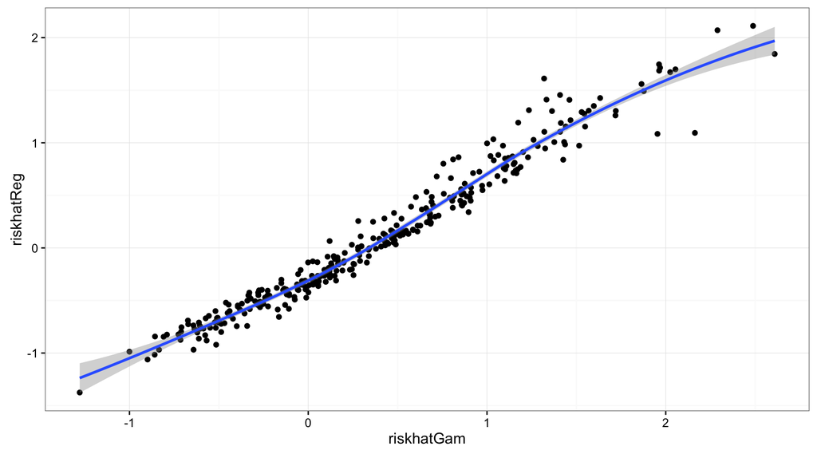

```r
form <- Surv(LKADT_P,DEATH=="YES") ~ log(ALP) + HB + log(AST) + log(PSA) + ALB +
  ECOG_C + LIVER + ADRENAL + LYMPH_NODES
survReg <- coxph(form, data= training)
riskhatReg <- predict(survReg, newdata = validation)
qplot(riskhatGam, riskhatReg) + geom_smooth()
```

The figure shows the scatter plot of the risk predictions on the validation data from the gam and the regression model.

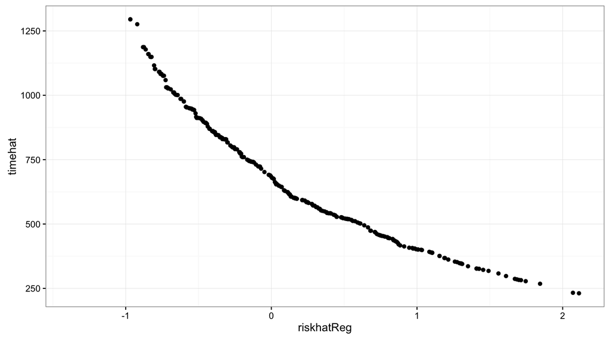

```r
timehat <- summary(survfit(survReg, newdata = validation))$table[, "median"]
qplot(riskhatReg, timehat)
```

The following table shows the predictions of survival times made from the model, and it is identical to the time-to-event predictions found in the file *nrhFinaltimetoevent.csv*.

```r
timehatValidation <-
  cbind(validation[, "RPT", drop = FALSE], data.frame(TIMETOEVENT = timehat))
timehatValidation
```

```
##          RPT TIMETOEVENT
## 1   AZ-00001         644
## 2   AZ-00003         976
## 3   AZ-00005        1027
## 4   AZ-00006         520
## 5   AZ-00007         829
## 6   AZ-00008         805
## 7   AZ-00010         861
## 8   AZ-00011         798
## 9   AZ-00012         458
## 10  AZ-00013         852
## 11  AZ-00014        1083
## 12  AZ-00016         790
## 13  AZ-00019         285
## 14  AZ-00020         401
```

[output cut: 299 more lines]

# Discussion

Based on our own validation studies and earlier submissions to the leaderboard, we expect a performance in terms of iAUC between 0.75 and 0.80. The addition of the ridge model to the gam is expected to give at most and increase of iAUC by 0.02. It could be interesting to investigate if boosting/bagging techniques could improve on the ridge component.

We did not try to include interactions between variables selected for the gam in any systematic way.

It was a little surprising that none of our attempts to come up with a clever handling of missing values had any positive impact on predictive performance. On the contrary.

There is one issue with the variable selection that is worth investigating further. The `glmnet` function standardizes all variables by default, which is sensible if they are all continuous, but less so if some are dummy variables encoding factor levels. We did some experiments with standardizing only the continuous predictors, but that did not appear to improve predictive performance in terms of iAUC.

# Author contributions